# Analysis of Police Reported Motor Vehicle Collisions in NYC

This website is from a GitHub repository with a deployed Github Pages. The repository with the index.html file can be found at: https://github.com/ben-rishel/MotorCollisionAnalysis

Motor vehicle collisions are a massive problem that plague society. It negatively impacts first responders, drivers, and pedestrians. To make policy decisions to reduce car crashes, it is very important to understand the issue at hand by analzying previous crash data. To get a good sample of crashes, analyzing New York City makes sense because it is the most populated city in the United States. The dataset being analyzed in this notebook is titled "Motor Vehicle Collisions - Crashes" and is from data.gov. It is inclusive of all collisions where either someone is injured, killed, or there is at least $1000 worth of damage in New York City. It has over 10 years of data which comes out to over 2 million rows. This dataset is extremely interesting because it contains the exact day and time of the crash, the number of injuries/deaths of people in the crash and pedestrians, the location, the reason for the crash, and the types of vehicles involved. There are some very interesting questions to investigate in regards to all of this information. This is incredibly important data because reducing car crashes is an important mission for the government and the recognition of patterns in this dataset can inform policy decisions to reduce crashes. Proper policy changes that reduce car crashes would improve the lives of many first responders, drivers, and pedestrians. It is also important to analyze trends in the data to see if previous policy changes had the desired impact and if they made any effect.

Some of the most pressing questions include:

1. How common are deaths in NYC motor collisions?
2. What types of cars are most responsible for crashes?
3. Is the problem getting worse year-to-year?
4. What times of the day are most common for crashes?
5. What times of the year are most common for crashes?
6. Which boroughs have the most crashes?
7. Which contributing factors to crashes are most common?

First, let's import the Pandas library and upload the data and begin to do some preliminary analysis about what all we can learn from the dataset. First, we will conduce exploratory data analysis of the data and then we will answer the 7 questions. Finally we will make overarching conclusions that may inform policy decisions.

```python
import pandas as pd
import numpy as np
import matplotlib.pyplot as plt
df = pd.read_csv("MotorCollisions.csv") #reading in csv
```

## Exploratory Data Analysis

```python
df.head()
```

|  | CRASH DATE | CRASH TIME | BOROUGH | ZIP CODE | LATITUDE | LONGITUDE | LOCATION | ON STREET NAME | CROSS STREET NAME | OFF STREET NAME | ... | CONTRIBUTING FACTOR VEHICLE 2 | CONTRIBUTING FACTOR VEHICLE 3 | CONTRIBUTING FACTOR VEHICLE 4 | CONTRIBUTING FACTOR VEHICLE 5 | COLLISION_ID | VEHICLE TYPE CODE 1 | VEHICLE TYPE CODE 2 | VEHICLE TYPE CODE 3 | VEHICLE TYPE CODE 4 | VEHICLE TYPE CODE 5 |
| --- | --- | --- | --- | --- | --- | --- | --- | --- | --- | --- | --- | --- | --- | --- | --- | --- | --- | --- | --- | --- | --- |
| 0 | 09/11/2021 | 2:39 | NaN | NaN | NaN | NaN | NaN | WHITESTONE EXPRESSWAY | 20 AVENUE | NaN | ... | Unspecified | NaN | NaN | NaN | 4455765 | Sedan | Sedan | NaN | NaN | NaN |
| 1 | 03/26/2022 | 11:45 | NaN | NaN | NaN | NaN | NaN | QUEENSBORO BRIDGE UPPER | NaN | NaN | ... | NaN | NaN | NaN | NaN | 4513547 | Sedan | NaN | NaN | NaN | NaN |
| 2 | 06/29/2022 | 6:55 | NaN | NaN | NaN | NaN | NaN | THROGS NECK BRIDGE | NaN | NaN | ... | Unspecified | NaN | NaN | NaN | 4541903 | Sedan | Pick-up Truck | NaN | NaN | NaN |
| 3 | 09/11/2021 | 9:35 | BROOKLYN | 11208.0 | 40.667202 | -73.866500 | (40.667202, -73.8665) | NaN | NaN | 1211 LORING AVENUE | ... | NaN | NaN | NaN | NaN | 4456314 | Sedan | NaN | NaN | NaN | NaN |
| 4 | 12/14/2021 | 8:13 | BROOKLYN | 11233.0 | 40.683304 | -73.917274 | (40.683304, -73.917274) | SARATOGA AVENUE | DECATUR STREET | NaN | ... | NaN | NaN | NaN | NaN | 4486609 | NaN | NaN | NaN | NaN | NaN |

5 rows × 29 columns

```python
df.shape
```

```
(2081608, 29)
```

There are 2,081,608 rows and 29 columns.

```python
df.duplicated().sum()
```

```
0
```

There are no duplicate values to deal with.

```python
df.isnull().sum()
```

```
CRASH DATE                             0
CRASH TIME                             0
BOROUGH                           647673
ZIP CODE                          647924
LATITUDE                          234060
LONGITUDE                         234060
LOCATION                          234060
ON STREET NAME                    442369
CROSS STREET NAME                 787625
OFF STREET NAME                  1731612
NUMBER OF PERSONS INJURED             18
NUMBER OF PERSONS KILLED              31
NUMBER OF PEDESTRIANS INJURED          0
NUMBER OF PEDESTRIANS KILLED           0
NUMBER OF CYCLIST INJURED              0
NUMBER OF CYCLIST KILLED               0
NUMBER OF MOTORIST INJURED             0
NUMBER OF MOTORIST KILLED              0
CONTRIBUTING FACTOR VEHICLE 1       6842
CONTRIBUTING FACTOR VEHICLE 2     323193
CONTRIBUTING FACTOR VEHICLE 3    1932774
CONTRIBUTING FACTOR VEHICLE 4    2047984
CONTRIBUTING FACTOR VEHICLE 5    2072488
COLLISION_ID                           0
VEHICLE TYPE CODE 1                13799
VEHICLE TYPE CODE 2               398747
VEHICLE TYPE CODE 3              1938182
VEHICLE TYPE CODE 4              2049153
VEHICLE TYPE CODE 5              2072767
dtype: int64
```

As you can see, we have lots of null values to deal with. While this is a bit unfortunate for our analysis, luckily the majority of the fields are qualitative so it is not detrimental to most of our calculations. In addition, the data set is so massive (over 2 million rows) that we will still have plenty of non-null data points to analyze. The .head() function excludes some of the column titles, so let's see what they all are:

```python
df.info()
```

```
<class 'pandas.core.frame.DataFrame'>
RangeIndex: 2081608 entries, 0 to 2081607
Data columns (total 29 columns):
 #   Column                         Dtype
---  ------                         -----
 0   CRASH DATE                     object
 1   CRASH TIME                     object
 2   BOROUGH                        object
 3   ZIP CODE                       object
 4   LATITUDE                       float64
 5   LONGITUDE                      float64
 6   LOCATION                       object
 7   ON STREET NAME                 object
 8   CROSS STREET NAME              object
 9   OFF STREET NAME                object
```

[output cut: 21 more lines]

We can also check out how many unique categories each column has:

```python
df.nunique()
```

```
CRASH DATE                          4308
CRASH TIME                          1440
BOROUGH                                5
ZIP CODE                             426
LATITUDE                          126690
LONGITUDE                          98406
LOCATION                          283980
ON STREET NAME                     18442
CROSS STREET NAME                  20253
OFF STREET NAME                   226980
NUMBER OF PERSONS INJURED             32
NUMBER OF PERSONS KILLED               7
NUMBER OF PEDESTRIANS INJURED         14
NUMBER OF PEDESTRIANS KILLED           4
NUMBER OF CYCLIST INJURED              5
NUMBER OF CYCLIST KILLED               3
NUMBER OF MOTORIST INJURED            31
NUMBER OF MOTORIST KILLED              6
CONTRIBUTING FACTOR VEHICLE 1         61
CONTRIBUTING FACTOR VEHICLE 2         61
CONTRIBUTING FACTOR VEHICLE 3         51
CONTRIBUTING FACTOR VEHICLE 4         41
CONTRIBUTING FACTOR VEHICLE 5         30
COLLISION_ID                     2081608
VEHICLE TYPE CODE 1                 1644
VEHICLE TYPE CODE 2                 1827
VEHICLE TYPE CODE 3                  262
VEHICLE TYPE CODE 4                  102
VEHICLE TYPE CODE 5                   71
dtype: int64
```

These values make sense. NYC has 5 boroughs and there are 1440 minutes in a day. Something that stands out is that there are over 1500 different vehicle type codes which will make it difficult to categorize the vehicles to see which types are most responsible. However, there is just 61 factors, so that will be easier to analyze.

We can summarize the float and integer values in the next cell:

```python
pd.options.display.float_format = '{:.2f}'.format #puts the values into 2 decimal format rather than sci. notation
df.describe()
```

|  | LATITUDE | LONGITUDE | NUMBER OF PERSONS INJURED | NUMBER OF PERSONS KILLED | NUMBER OF PEDESTRIANS INJURED | NUMBER OF PEDESTRIANS KILLED | NUMBER OF CYCLIST INJURED | NUMBER OF CYCLIST KILLED | NUMBER OF MOTORIST INJURED | NUMBER OF MOTORIST KILLED | COLLISION_ID |
| --- | --- | --- | --- | --- | --- | --- | --- | --- | --- | --- | --- |
| count | 1847548.00 | 1847548.00 | 2081590.00 | 2081577.00 | 2081608.00 | 2081608.00 | 2081608.00 | 2081608.00 | 2081608.00 | 2081608.00 | 2081608.00 |
| mean | 40.63 | -73.75 | 0.31 | 0.00 | 0.06 | 0.00 | 0.03 | 0.00 | 0.22 | 0.00 | 3164245.65 |
| std | 1.98 | 3.73 | 0.70 | 0.04 | 0.24 | 0.03 | 0.16 | 0.01 | 0.66 | 0.03 | 1505294.68 |
| min | 0.00 | -201.36 | 0.00 | 0.00 | 0.00 | 0.00 | 0.00 | 0.00 | 0.00 | 0.00 | 22.00 |
| 25% | 40.67 | -73.97 | 0.00 | 0.00 | 0.00 | 0.00 | 0.00 | 0.00 | 0.00 | 0.00 | 3156521.75 |
| 50% | 40.72 | -73.93 | 0.00 | 0.00 | 0.00 | 0.00 | 0.00 | 0.00 | 0.00 | 0.00 | 3677045.50 |
| 75% | 40.77 | -73.87 | 0.00 | 0.00 | 0.00 | 0.00 | 0.00 | 0.00 | 0.00 | 0.00 | 4197694.25 |
| max | 43.34 | 0.00 | 43.00 | 8.00 | 27.00 | 6.00 | 4.00 | 2.00 | 43.00 | 5.00 | 4718429.00 |

This data reveals several important pieces of information. For one, the average of number of persons killed being 0 is a bit surprising, but I suppose it makes sense given the size of the dataset. It also shows that the mean of numbr of motorist injured is the highest, pedestrians second, and cyclists third. We can further explore the spread of some of the variables using some histograms:

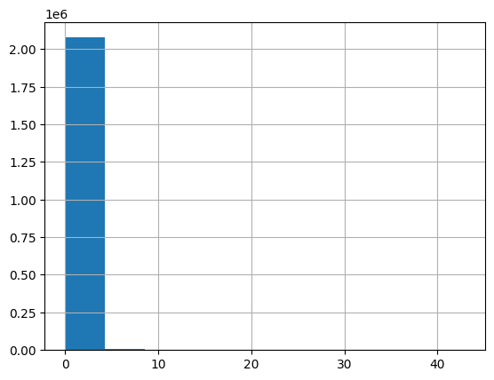

```python
df['NUMBER OF PERSONS INJURED'].hist()
```

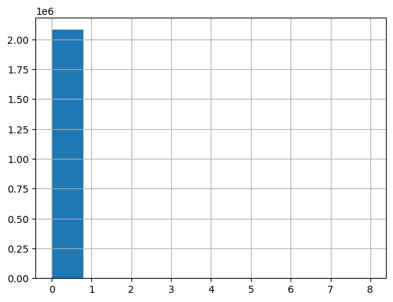

```python
df['NUMBER OF PERSONS KILLED'].hist()
```

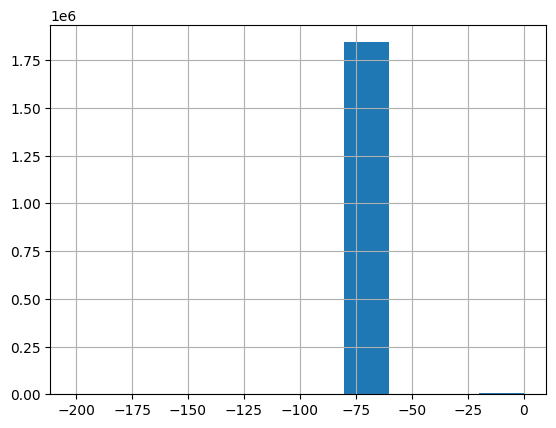

```python
df['LONGITUDE'].hist()
```

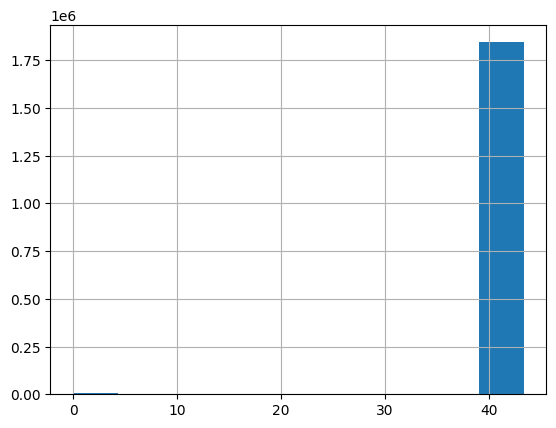

```python
df['LATITUDE'].hist()
```

## 1. How common are deaths in NYC motor collisions?

To determine how common deaths are, we can show numerically the number of times each number of deaths occured, we can show the percentage of each of these occurences, and we can show a bar chart that shows the spread of number of deaths reported in each collision.

```python
df['NUMBER OF PERSONS KILLED'].value_counts() #Creates frequency table
```

```
NUMBER OF PERSONS KILLED
0.00    2078581
1.00       2903
2.00         75
3.00         12
4.00          3
5.00          2
8.00          1
Name: count, dtype: int64
```

Above shows that the vast majority of all collisions resulted in no deaths. However, there were still about 3,000 times at least one person died.

```python
(df['NUMBER OF PERSONS KILLED'].value_counts()/df['NUMBER OF PERSONS KILLED'].count())*100 #frequency table in terms of percents
```

```
NUMBER OF PERSONS KILLED
0.00   99.86
1.00    0.14
2.00    0.00
3.00    0.00
4.00    0.00
5.00    0.00
8.00    0.00
Name: count, dtype: float64
```

This shows that as a percent, 0 deaths occur in 99.86% of all collisions in the data.

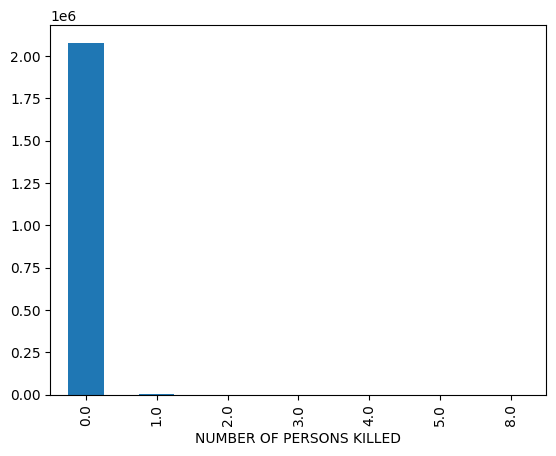

```python
df['NUMBER OF PERSONS KILLED'].value_counts().plot.bar(x='# Killed', y='Frequency')
```

Due to the dominance of 0 in the data, the other values do not even appear. We can create a histogram excluding 0s to show how the number of deaths are distributed. In the code cell below, we temporarily create a df2 object that has all zero values replace with NaN values, so that they are ignored.

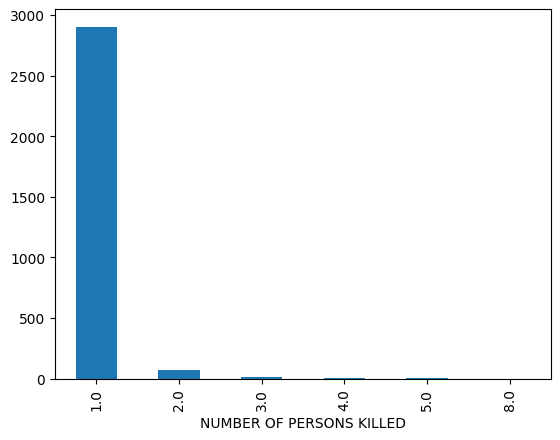

```python
df2 = df.replace(0, np.nan)
df2['NUMBER OF PERSONS KILLED'].value_counts().plot.bar(x='# Killed', y='Frequency')
```

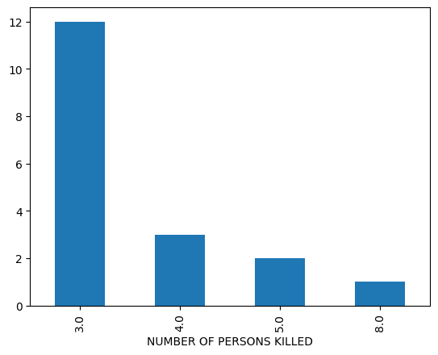

```python
df2 = df2.replace(1, np.nan)
df2 = df2.replace(2, np.nan)
df2['NUMBER OF PERSONS KILLED'].value_counts().plot.bar(x='# Killed', y='Frequency')
```

## 2. What types of cars are most responsible for crashes?

To analyze which types of cars are most responsible for crashes, we can focus on the Vehicle Type Code 1 and 2 columns of the dataframe. This is because they have a significantly smaller proportion of nulls as compared to 3, 4, and 5 which makes sense because the majority of car crashes are just two cars. We can start by just printing the value_counts of each column to get an idea of what we are working with:

```python
df['VEHICLE TYPE CODE 1'].value_counts()
```

```
VEHICLE TYPE CODE 1
Sedan                                  579431
Station Wagon/Sport Utility Vehicle    455687
PASSENGER VEHICLE                      416206
SPORT UTILITY / STATION WAGON          180291
Taxi                                    51707
                                        ...
AMbul                                       1
Gator 4x4                                   1
ABULANCE                                    1
ARMY                                        1
Electric M                                  1
Name: count, Length: 1644, dtype: int64
```

```python
df['VEHICLE TYPE CODE 2'].value_counts()
```

```
VEHICLE TYPE CODE 2
Sedan                                  405184
Station Wagon/Sport Utility Vehicle    327791
PASSENGER VEHICLE                      318607
SPORT UTILITY / STATION WAGON          140204
UNKNOWN                                 81507
                                        ...
ART M                                       1
FD TR                                       1
van a                                       1
Skate                                       1
MARSH ,OPE                                  1
Name: count, Length: 1827, dtype: int64
```

Due to the massive length of each of these (1644 and 1827) it is difficult to perform an analysis. However, we can see that a bunch of the categories at the bottom are unique and have a count of just 1. Instead of taking the time to individually classify each of these into one of the large categories, we can instead just ignore anything that has a small count. To do this we can perform our analysis on the top 10 categories.

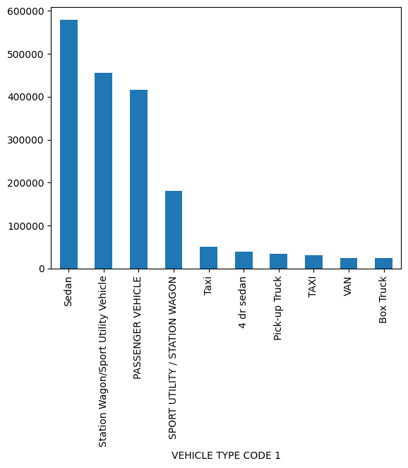

```python
df['VEHICLE TYPE CODE 1'].value_counts().head(10).plot.bar()
```

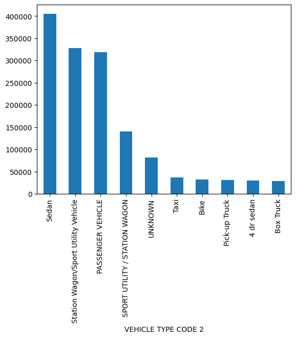

```python
df['VEHICLE TYPE CODE 2'].value_counts().head(10).plot.bar()
```

There are lots of interesting conclusions to make about these charts. First of all, it makes sense the Sedan, Station Wagon/SUV, and Passenger Vehicle, are the top 3. It is unclear what the passenger vehicle refers to, but I assume that is an unspecificied reference to either a Sedan or SUV. Also, the fourth category is also SUV but just with a different format. If you pay attention to the y-axis, it is easy to see that the vehicle type code 1 have higher frequencies. This is because there are more null values for the second vehicle because single car crashes can happen. Also, in hit and run incidents, it is often that the second car is not found. This would also explain the frequency of the 'UNKNOWN' category for the second vehicle. It also is interesting that bikes are in the top 10 for secondary vehicles. This is likely bikers getting hit by cars. It is slightly surprising that trucks are so rare, but it makes sense given the context of New York City. It is more rare to have a truck in a big city than a suburban or rural area.

## 3. Is the problem getting worse year-to-year?

To analyze how the problem of car crashes has progressed year to year, we can analyze a few different things. First of all, we have to define what we mean by "worse". We can define "worse" in terms of number of crashes, injuries, or deaths. Rather than boxing ourselves into just one, let's analyze each of these. We can rely on the crash date column to conduct time series analysis of these variables. First we must convert to datetime objects.

```python
df['CRASH DATE'] = pd.to_datetime(df['CRASH DATE']) #converting to datetime objects
```

Now, we can perform mathematical operations on the data. To show these capabilites, we can view the min and max (or the start and end dates) of the crash date data.

```python
df['CRASH DATE'].min()
```

```
Timestamp('2012-07-01 00:00:00')
```

```python
df['CRASH DATE'].max()
```

```
Timestamp('2024-04-16 00:00:00')
```

To construct our graphs, it is important to understand how many days/months/years we are working with. By subtracting the datetime objects we can find how many days apart they are.

```python
(df['CRASH DATE'].max() - df['CRASH DATE'].min())
```

```
Timedelta('4307 days 00:00:00')
```

Now, we can graph based upon the number of crashes per day. To graph this, we must create a new dataframe that is grouped by the crash date. Then we can plot a line graph with the values sorted.

```python
crash_dateDF = pd.DataFrame(df['CRASH DATE'].value_counts())
```

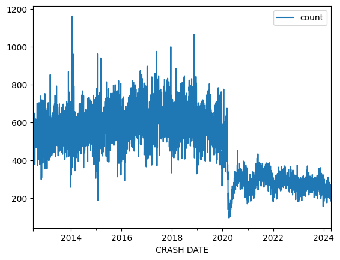

```python
crash_dateDF.sort_values(by=['CRASH DATE']).plot()
```

The graph above makes it hard to tell exactly what is going on because of how many lines there are. We can get more specific by limiting the vertical lines to months. We can do this by temporarily changing the datetime object to just including the year and month.

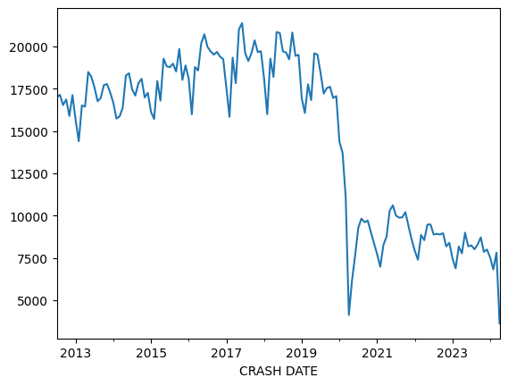

```python
import datetime as dt
monthDF = df.sort_values(by=['CRASH DATE'])['CRASH DATE'].dt.to_period('M') #switches to just the month and year
monthDF.value_counts(sort=False).plot() #don't want to sort by values
```

This provides a smoother analysis of the trend, but we can make it even smoother by doing it based on year. After the year chart we can analyze the trends on a year-to-year basis to help answer our original question.

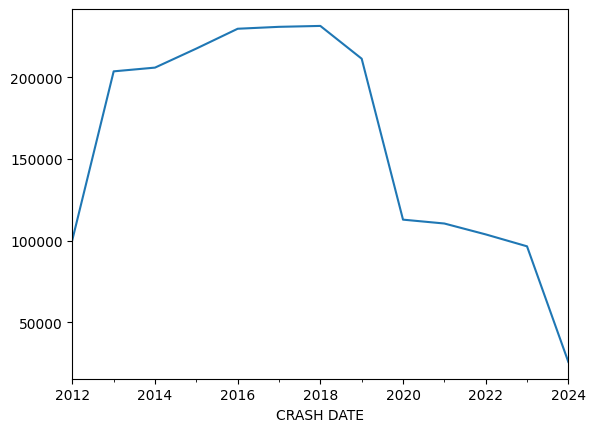

```python
yearDF = df.sort_values(by=['CRASH DATE'])['CRASH DATE'].dt.to_period('Y')
yearDF.value_counts(sort=False).plot()
```

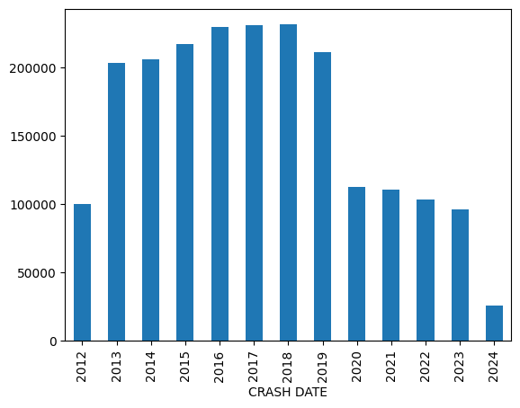

```python
yearDF.value_counts(sort=False).plot(kind='bar')
```

The bar chart and the last chart present the same information. Our initial question is whether or not the problem of car crashes was getting worse. From this dataset, it is clear that rather than getting worse, it is in fact getting better. The frequency of crashes (or at least those reported) peaked in 2018 and have declined since. The steep decline from 2019-2020/2021 can be attributed to the Covid pandemic, but that does not explain why there have been continually less crashes since. The 2024 data is so low because of the data is incomplete as it only goes up to 4/16/2024. This data is very encouraging but there are several reasons this could not be entirely accurate. For one, many car crashes likely go unreported. Based on the data we have available the problem of car collisions in NYC has been improving in terms of number of crashes. Now, we will produce the same graphs as above but in terms of number of injuries and deaths and make observations about them below.

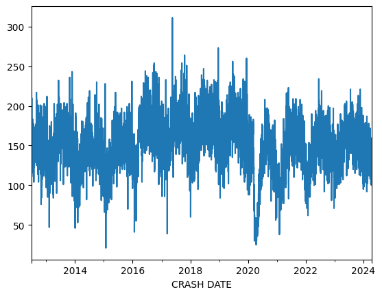

```python
df['NUMBER OF PERSONS INJURED'].groupby(df['CRASH DATE']).sum().plot()
```

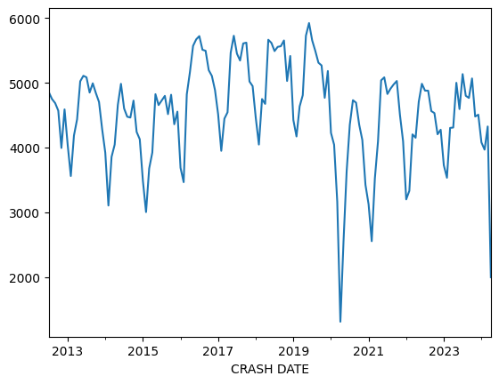

```python
df['NUMBER OF PERSONS INJURED'].groupby(df['CRASH DATE'].dt.to_period('M')).sum().plot()
```

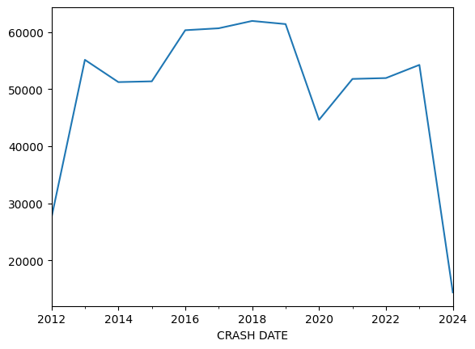

```python
df['NUMBER OF PERSONS INJURED'].groupby(df['CRASH DATE'].dt.to_period('Y')).sum().plot()
```

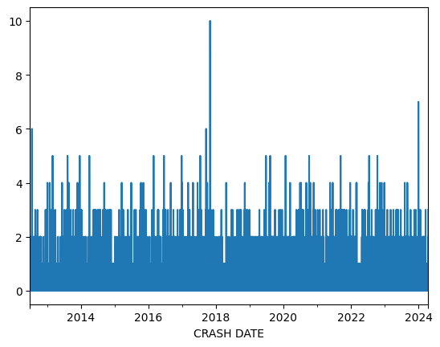

```python
df['NUMBER OF PERSONS KILLED'].groupby(df['CRASH DATE']).sum().plot()
```

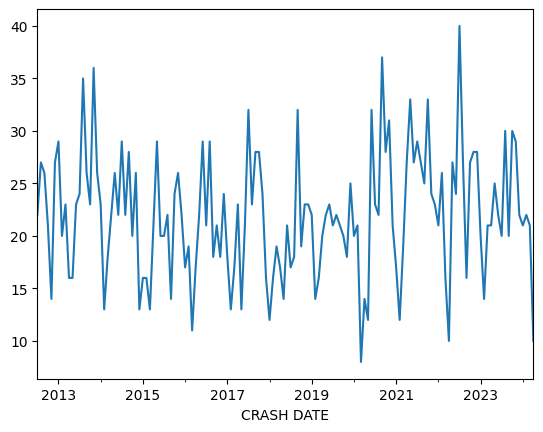

```python
df['NUMBER OF PERSONS KILLED'].groupby(df['CRASH DATE'].dt.to_period('M')).sum().plot()
```

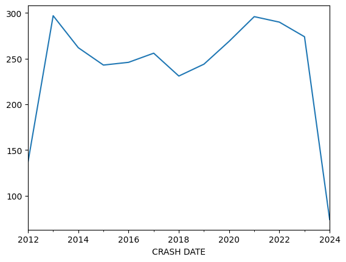

```python
df['NUMBER OF PERSONS KILLED'].groupby(df['CRASH DATE'].dt.to_period('Y')).sum().plot()
```

Unexpectedly, the injury charts have less severe of a drop off than the frequency of crash charts. In addition, the number of deaths really have not declined despite the decline in number of crashes. This leads me to believe that the reason for the drop in crash is a reporting issue. It would make sense that less severe crashes do not need to be reported. Most likely a crash without any injury would result in the two parties exchanging insurance information and then going on with their lives. If the crash is serious enough to cause an injury, and especially a death, it is much more likely that authorities would be involved. It would appear as though more crashes are going unreported now. So, to answer our initial question: There is inconclusive evidence as to whether or not the problem is getting worse. There are significantly less crashes reported, and marginally less injuries, but the death amount is still roughly the same if not worse than it was 5 years ago.

## 4. What times of the day are most common for crashes?

To determine what times of day are most common we can apply the value count method to the crash time column. We will have to first convert the column to datetime objects. We would expect most crashes to happen around rush hours, so 7-9 AM and 5-7 PM.

```python
df.head()
```

|  | CRASH DATE | CRASH TIME | BOROUGH | ZIP CODE | LATITUDE | LONGITUDE | LOCATION | ON STREET NAME | CROSS STREET NAME | OFF STREET NAME | ... | CONTRIBUTING FACTOR VEHICLE 2 | CONTRIBUTING FACTOR VEHICLE 3 | CONTRIBUTING FACTOR VEHICLE 4 | CONTRIBUTING FACTOR VEHICLE 5 | COLLISION_ID | VEHICLE TYPE CODE 1 | VEHICLE TYPE CODE 2 | VEHICLE TYPE CODE 3 | VEHICLE TYPE CODE 4 | VEHICLE TYPE CODE 5 |
| --- | --- | --- | --- | --- | --- | --- | --- | --- | --- | --- | --- | --- | --- | --- | --- | --- | --- | --- | --- | --- | --- |
| 0 | 2021-09-11 | 2:39 | NaN | NaN | NaN | NaN | NaN | WHITESTONE EXPRESSWAY | 20 AVENUE | NaN | ... | Unspecified | NaN | NaN | NaN | 4455765 | Sedan | Sedan | NaN | NaN | NaN |
| 1 | 2022-03-26 | 11:45 | NaN | NaN | NaN | NaN | NaN | QUEENSBORO BRIDGE UPPER | NaN | NaN | ... | NaN | NaN | NaN | NaN | 4513547 | Sedan | NaN | NaN | NaN | NaN |
| 2 | 2022-06-29 | 6:55 | NaN | NaN | NaN | NaN | NaN | THROGS NECK BRIDGE | NaN | NaN | ... | Unspecified | NaN | NaN | NaN | 4541903 | Sedan | Pick-up Truck | NaN | NaN | NaN |
| 3 | 2021-09-11 | 9:35 | BROOKLYN | 11208.00 | 40.67 | -73.87 | (40.667202, -73.8665) | NaN | NaN | 1211 LORING AVENUE | ... | NaN | NaN | NaN | NaN | 4456314 | Sedan | NaN | NaN | NaN | NaN |
| 4 | 2021-12-14 | 8:13 | BROOKLYN | 11233.00 | 40.68 | -73.92 | (40.683304, -73.917274) | SARATOGA AVENUE | DECATUR STREET | NaN | ... | NaN | NaN | NaN | NaN | 4486609 | NaN | NaN | NaN | NaN | NaN |

5 rows × 29 columns

```python
df['CRASH TIME'] = pd.to_datetime(df['CRASH TIME'], format='%H:%M')
df['CRASH TIME'] = df['CRASH TIME'].dt.time #converting to just time to chop off date
timeDF = df.sort_values(by=['CRASH TIME'])
```

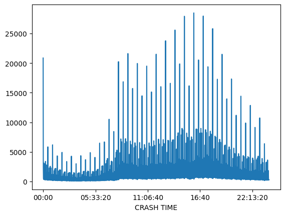

```python
timeDF['CRASH TIME'].value_counts(sort=False).plot()
```

The above chart shows the frequency of crashes at each time during the day. Clearly, there are limited crashes between midnight and about 6 AM. The amount of crashes increase during rush hour in the morning, as I predicted, and continue to rise until a peak at evening rush hour around 4-5 PM. Then they slowly decline until they cycle back to their minimum in the middle of the night. This all seems to make sense except for the fact that it is a little surprising that the frequency of morning rush hour crashes is about the same as it is until the afternoon and early evening. I'm surprised there is as many crashes at 11 AM as there is when everyone is driving to work in the morning. To answer the original question: The most common time for crashes is 4 P.M as displayed in the next code block.

```python
timeDF['CRASH TIME'].value_counts()
```

```
CRASH TIME
16:00:00    28459
17:00:00    27938
15:00:00    27898
18:00:00    25808
14:00:00    25574
            ...
05:31:00      104
03:31:00       99
03:59:00       99
02:31:00       96
04:31:00       94
Name: count, Length: 1440, dtype: int64
```

## 5. What times of the year are most common for crashes?

It would make sense for the amount of crashes per month to be about equal regardless of the month. However, I would expect a slight uptick in the winter months due to the danger of driving in the ice and snow. Let's create a bar graph to compare the various months.

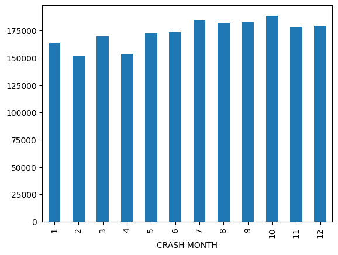

```python
df['CRASH DATE'] = pd.to_datetime(df['CRASH DATE'])
monthDF = df.copy() #creating a copy to be mutated
monthDF['CRASH MONTH'] = pd.DatetimeIndex(df['CRASH DATE']).month #just keeping the month
monthDF = monthDF.sort_values(by=['CRASH MONTH']) #sorting by month
monthDF['CRASH MONTH'].value_counts(sort=False).plot(kind = 'bar')
```

Surprisingly, there are more crashes in the late summer months and early fall months. October has the most crashes which I am unsure of why that would be.

## 6. Which boroughs have the most crashes?

According to a 2022 Census, Brooklyn had a population of 2.6 million, Queens 2.3 million, Manhattan 1.6 million, Bronx 1.4 million, and Staten Island 500k. Thus, I would expect the crashes to be strongly correlated to that information. We can perform a simple value count analysis to find out the truth.

```python
df['BOROUGH'].value_counts()
```

```
BOROUGH
BROOKLYN         456248
QUEENS           384472
MANHATTAN        320957
BRONX            212067
STATEN ISLAND     60191
Name: count, dtype: int64
```

As expected, the number of crashes reflect the descrepancies in population. However, I wonder if is proportional? Let's find out.

```python
borS = df['BOROUGH'].value_counts() #converting to series
popS = pd.Series(np.array([2600000,2300000,1600000,1400000,500000]), index = ['BROOKLYN', 'QUEENS', 'MANHATTAN', 'BRONX', 'STATEN ISLAND']) #series with populations
borS/popS #creating per capita crashes
```

```
BOROUGH
BROOKLYN         0.175480
QUEENS           0.167162
MANHATTAN        0.200598
BRONX            0.151476
STATEN ISLAND    0.120382
dtype: float64
```

This shows that since 2012, the per capita motor collisions is worst in Manhattan. This shows that the issue of crashes does not necessarily get worse proportional to the population. If that was the case, Brooklyn would have the worst per capita motor collisions. So, to answer the question, Brooklyn has the most crashes in total, but Manhattan has the most per capita (according to 2022 census populations).